# INTRODUCTION OF DATASET

The DataSet is taken from the Bank Marketing campaigns (phone calls) of a Portuguese banking institution

**BUSINESS PROBLEM Statement:** To find out the factors which will help bank to run efficient marketing campaigns and make calls to those customers who are most interested to subscribe for term deposits offered by the bank.

**AIM of the Project**

The Aim is to predict if the client will subscribe a term deposit and identify factors that may improve the bank’s marketing strategies to attract more customers to get a term deposit.

**Attributes Explanation**

**Input variables:** **age, job, marital, education** are self explanatory

**default**: Does the customer have credit in default

**Balance**: Balance of the customer

**housing**: Does the customer have a housing loan

**loan**: Does the customer have a personal loan

**Related with the last contact of the current campaign:**

**Contact**: contact communication type

**Month**: last contact month of year ("jan", "feb", "mar", ..., "nov", "dec")

**Duration**: last contact duration, in seconds. *Important note:* this attribute highly affects the output target (e.g., if duration=0 then y="no").

**Other attributes:**

**Campaign**: Number of contacts performed during this campaign and for this client includes last contact

**pdays**: Number of days that passed by after the client was last contacted from a previous campaign (999 means client was not previously contacted)

**Previous**: number of contacts performed before this campaign and for this client

**poutcome**: outcome of the previous marketing campaign (categorical: "failure","nonexistent","success")

**Outcome variable(y)**- has the client subscribed to a term deposit? ("yes","no")

**Importing Libraries**

```python
# Importing necessary libraries
import numpy as np  # Mathematical calculations, extra faster functions
import pandas as pd # For data loading and manipulation
import matplotlib.pyplot as plt  # Visualization tool (Can create complex custom charts)
import seaborn as sns # Visualization tool (in-build high quality charts)
import warnings
warnings.filterwarnings('ignore')  # This method will ignore all warnings.
```

# Basic Exploration

```python
bank_full=pd.read_csv('bank-full.csv',sep=';') # reading the bankfull dataset using pandas and use separater
```

```python
bank_full.shape # to check rows and columns
```

```
(45211, 17)
```

```python
bank=pd.read_csv('bank.csv',sep=';') # reading the bank dataset using pandas and use separater
```

```python
bank.shape # to check rows and columns in randomly selected dataset
```

```
(4521, 17)
```

*Merging bank_full and bank datasets into a single dataframe and to perform further analysis*

```python
bank_marketing=pd.concat([bank_full,bank],ignore_index=True) # merging both datasets
```

```python
bank_marketing.shape # View dimensionality of the dataset
```

```
(49732, 17)
```

```python
bank_marketing.head() # shows top 5 rows in dataframe
```

|  | age | job | marital | education | default | balance | housing | loan | contact | day | month | duration | campaign | pdays | previous | poutcome | y |
| --- | --- | --- | --- | --- | --- | --- | --- | --- | --- | --- | --- | --- | --- | --- | --- | --- | --- |
| 0 | 58 | management | married | tertiary | no | 2143 | yes | no | unknown | 5 | may | 261 | 1 | -1 | 0 | unknown | no |
| 1 | 44 | technician | single | secondary | no | 29 | yes | no | unknown | 5 | may | 151 | 1 | -1 | 0 | unknown | no |
| 2 | 33 | entrepreneur | married | secondary | no | 2 | yes | yes | unknown | 5 | may | 76 | 1 | -1 | 0 | unknown | no |
| 3 | 47 | blue-collar | married | unknown | no | 1506 | yes | no | unknown | 5 | may | 92 | 1 | -1 | 0 | unknown | no |
| 4 | 33 | unknown | single | unknown | no | 1 | no | no | unknown | 5 | may | 198 | 1 | -1 | 0 | unknown | no |

```python
bank_marketing.tail() # shows bottom 5 rows
```

|  | age | job | marital | education | default | balance | housing | loan | contact | day | month | duration | campaign | pdays | previous | poutcome | y |
| --- | --- | --- | --- | --- | --- | --- | --- | --- | --- | --- | --- | --- | --- | --- | --- | --- | --- |
| 49727 | 33 | services | married | secondary | no | -333 | yes | no | cellular | 30 | jul | 329 | 5 | -1 | 0 | unknown | no |
| 49728 | 57 | self-employed | married | tertiary | yes | -3313 | yes | yes | unknown | 9 | may | 153 | 1 | -1 | 0 | unknown | no |
| 49729 | 57 | technician | married | secondary | no | 295 | no | no | cellular | 19 | aug | 151 | 11 | -1 | 0 | unknown | no |
| 49730 | 28 | blue-collar | married | secondary | no | 1137 | no | no | cellular | 6 | feb | 129 | 4 | 211 | 3 | other | no |
| 49731 | 44 | entrepreneur | single | tertiary | no | 1136 | yes | yes | cellular | 3 | apr | 345 | 2 | 249 | 7 | other | no |

```python
bank_marketing.info() # to check dataset summary.
```

```
<class 'pandas.core.frame.DataFrame'>
RangeIndex: 49732 entries, 0 to 49731
Data columns (total 17 columns):
 #   Column     Non-Null Count  Dtype
---  ------     --------------  -----
 0   age        49732 non-null  int64
 1   job        49732 non-null  object
 2   marital    49732 non-null  object
 3   education  49732 non-null  object
 4   default    49732 non-null  object
 5   balance    49732 non-null  int64
 6   housing    49732 non-null  object
 7   loan       49732 non-null  object
 8   contact    49732 non-null  object
 9   day        49732 non-null  int64
 10  month      49732 non-null  object
 11  duration   49732 non-null  int64
 12  campaign   49732 non-null  int64
 13  pdays      49732 non-null  int64
 14  previous   49732 non-null  int64
 15  poutcome   49732 non-null  object
 16  y          49732 non-null  object
dtypes: int64(7), object(10)
memory usage: 6.5+ MB
```

```python
bank_marketing.describe() # Provides descriptive information about the data.
```

|  | age | balance | day | duration | campaign | pdays | previous |
| --- | --- | --- | --- | --- | --- | --- | --- |
| count | 49732.000000 | 49732.000000 | 49732.000000 | 49732.000000 | 49732.000000 | 49732.000000 | 49732.000000 |
| mean | 40.957472 | 1367.761562 | 15.816315 | 258.690179 | 2.766549 | 40.158630 | 0.576892 |
| std | 10.615008 | 3041.608766 | 8.315680 | 257.743149 | 3.099075 | 100.127123 | 2.254838 |
| min | 18.000000 | -8019.000000 | 1.000000 | 0.000000 | 1.000000 | -1.000000 | 0.000000 |
| 25% | 33.000000 | 72.000000 | 8.000000 | 103.000000 | 1.000000 | -1.000000 | 0.000000 |
| 50% | 39.000000 | 448.000000 | 16.000000 | 180.000000 | 2.000000 | -1.000000 | 0.000000 |
| 75% | 48.000000 | 1431.000000 | 21.000000 | 320.000000 | 3.000000 | -1.000000 | 0.000000 |
| max | 95.000000 | 102127.000000 | 31.000000 | 4918.000000 | 63.000000 | 871.000000 | 275.000000 |

# Data Preparation

```python
bank_marketing = bank_marketing.drop_duplicates() # dropping the dublicates from the bank_marketing dataset
```

```python
bank_marketing.shape # after removing duplicates shape
```

```
(45211, 17)
```

Merging both datasets will only lead to duplication so bank dataset is derived from bank_full dataset so our main dataframe bank_marketing has 45211 rows and 17 columns.

```python
bm=bank_marketing.copy() # creating a copy of main dataframe into new one 'bm'
test=bank_marketing.copy()
```

# Variable Understanding

```python
bm.info() # for getting information of dataset
```

```
<class 'pandas.core.frame.DataFrame'>
Int64Index: 45211 entries, 0 to 45210
Data columns (total 17 columns):
 #   Column     Non-Null Count  Dtype
---  ------     --------------  -----
 0   age        45211 non-null  int64
 1   job        45211 non-null  object
 2   marital    45211 non-null  object
 3   education  45211 non-null  object
 4   default    45211 non-null  object
 5   balance    45211 non-null  int64
 6   housing    45211 non-null  object
 7   loan       45211 non-null  object
 8   contact    45211 non-null  object
 9   day        45211 non-null  int64
 10  month      45211 non-null  object
 11  duration   45211 non-null  int64
 12  campaign   45211 non-null  int64
 13  pdays      45211 non-null  int64
 14  previous   45211 non-null  int64
 15  poutcome   45211 non-null  object
 16  y          45211 non-null  object
dtypes: int64(7), object(10)
memory usage: 6.2+ MB
```

If we observe categorical columns datatype is showing object which is incorrect so let's change them below...

```python
col = ['job','marital','education','default','housing','loan','contact','month','poutcome','y'] # columns for conversion which are showing as object dataypes
bm[col]=bm[col].astype('category')
bm.info()
```

```
<class 'pandas.core.frame.DataFrame'>
Int64Index: 45211 entries, 0 to 45210
Data columns (total 17 columns):
 #   Column     Non-Null Count  Dtype
---  ------     --------------  -----
 0   age        45211 non-null  int64
 1   job        45211 non-null  category
 2   marital    45211 non-null  category
 3   education  45211 non-null  category
 4   default    45211 non-null  category
 5   balance    45211 non-null  int64
 6   housing    45211 non-null  category
 7   loan       45211 non-null  category
 8   contact    45211 non-null  category
 9   day        45211 non-null  int64
 10  month      45211 non-null  category
 11  duration   45211 non-null  int64
 12  campaign   45211 non-null  int64
 13  pdays      45211 non-null  int64
 14  previous   45211 non-null  int64
 15  poutcome   45211 non-null  category
 16  y          45211 non-null  category
dtypes: category(10), int64(7)
memory usage: 3.2 MB
```

**Obervation :**

objects variables = 10

numericals variables = 7

```python
bm.nunique() # getting unique values
```

```
age            77
job            12
marital         3
education       4
default         2
balance      7168
housing         2
loan            2
contact         3
day            31
month          12
duration     1573
campaign       48
pdays         559
previous       41
poutcome        4
y               2
dtype: int64
```

- There is no feature with unique value

```python
bm.isnull().sum() # to check null values
```

```
age          0
job          0
marital      0
education    0
default      0
balance      0
housing      0
loan         0
contact      0
day          0
month        0
duration     0
campaign     0
pdays        0
previous     0
poutcome     0
y            0
dtype: int64
```

```python
bm.isna() # to detect missing values in dataframe
```

|  | age | job | marital | education | default | balance | housing | loan | contact | day | month | duration | campaign | pdays | previous | poutcome | y |
| --- | --- | --- | --- | --- | --- | --- | --- | --- | --- | --- | --- | --- | --- | --- | --- | --- | --- |
| 0 | False | False | False | False | False | False | False | False | False | False | False | False | False | False | False | False | False |
| 1 | False | False | False | False | False | False | False | False | False | False | False | False | False | False | False | False | False |
| 2 | False | False | False | False | False | False | False | False | False | False | False | False | False | False | False | False | False |
| 3 | False | False | False | False | False | False | False | False | False | False | False | False | False | False | False | False | False |
| 4 | False | False | False | False | False | False | False | False | False | False | False | False | False | False | False | False | False |
| ... | ... | ... | ... | ... | ... | ... | ... | ... | ... | ... | ... | ... | ... | ... | ... | ... | ... |
| 45206 | False | False | False | False | False | False | False | False | False | False | False | False | False | False | False | False | False |
| 45207 | False | False | False | False | False | False | False | False | False | False | False | False | False | False | False | False | False |
| 45208 | False | False | False | False | False | False | False | False | False | False | False | False | False | False | False | False | False |
| 45209 | False | False | False | False | False | False | False | False | False | False | False | False | False | False | False | False | False |
| 45210 | False | False | False | False | False | False | False | False | False | False | False | False | False | False | False | False | False |

45211 rows × 17 columns

```python
bm.isna().sum() # missing values count column wise
```

```
age          0
job          0
marital      0
education    0
default      0
balance      0
housing      0
loan         0
contact      0
day          0
month        0
duration     0
campaign     0
pdays        0
previous     0
poutcome     0
y            0
dtype: int64
```

*We have zero missing and zero null values in dataframe*

```python
bm.describe() # shows the numerical columns with statistical data
```

|  | age | balance | day | duration | campaign | pdays | previous |
| --- | --- | --- | --- | --- | --- | --- | --- |
| count | 45211.000000 | 45211.000000 | 45211.000000 | 45211.000000 | 45211.000000 | 45211.000000 | 45211.000000 |
| mean | 40.936210 | 1362.272058 | 15.806419 | 258.163080 | 2.763841 | 40.197828 | 0.580323 |
| std | 10.618762 | 3044.765829 | 8.322476 | 257.527812 | 3.098021 | 100.128746 | 2.303441 |
| min | 18.000000 | -8019.000000 | 1.000000 | 0.000000 | 1.000000 | -1.000000 | 0.000000 |
| 25% | 33.000000 | 72.000000 | 8.000000 | 103.000000 | 1.000000 | -1.000000 | 0.000000 |
| 50% | 39.000000 | 448.000000 | 16.000000 | 180.000000 | 2.000000 | -1.000000 | 0.000000 |
| 75% | 48.000000 | 1428.000000 | 21.000000 | 319.000000 | 3.000000 | -1.000000 | 0.000000 |
| max | 95.000000 | 102127.000000 | 31.000000 | 4918.000000 | 63.000000 | 871.000000 | 275.000000 |

If we observe the difference between mean and standard deviation is very high for balance, pdays columns and also between 75th percentile and max value is very high which indicates skewness for duration, campaign, pdays and previous columns

```python
bm.describe(include='category')  # shows the categorical columns with statistical data
```

|  | job | marital | education | default | housing | loan | contact | month | poutcome | y |
| --- | --- | --- | --- | --- | --- | --- | --- | --- | --- | --- |
| count | 45211 | 45211 | 45211 | 45211 | 45211 | 45211 | 45211 | 45211 | 45211 | 45211 |
| unique | 12 | 3 | 4 | 2 | 2 | 2 | 3 | 12 | 4 | 2 |
| top | blue-collar | married | secondary | no | yes | no | cellular | may | unknown | no |
| freq | 9732 | 27214 | 23202 | 44396 | 25130 | 37967 | 29285 | 13766 | 36959 | 39922 |

```
      If we see top frequency is high in factors like Credit_Status,PreviousOutcome and Term_deposit which shows imbalance in the data
```

```python
bm.describe(include='all') # get dataframe's descriptive statistics for all columns
```

|  | age | job | marital | education | default | balance | housing | loan | contact | day | month | duration | campaign | pdays | previous | poutcome | y |
| --- | --- | --- | --- | --- | --- | --- | --- | --- | --- | --- | --- | --- | --- | --- | --- | --- | --- |
| count | 45211.000000 | 45211 | 45211 | 45211 | 45211 | 45211.000000 | 45211 | 45211 | 45211 | 45211.000000 | 45211 | 45211.000000 | 45211.000000 | 45211.000000 | 45211.000000 | 45211 | 45211 |
| unique | NaN | 12 | 3 | 4 | 2 | NaN | 2 | 2 | 3 | NaN | 12 | NaN | NaN | NaN | NaN | 4 | 2 |
| top | NaN | blue-collar | married | secondary | no | NaN | yes | no | cellular | NaN | may | NaN | NaN | NaN | NaN | unknown | no |
| freq | NaN | 9732 | 27214 | 23202 | 44396 | NaN | 25130 | 37967 | 29285 | NaN | 13766 | NaN | NaN | NaN | NaN | 36959 | 39922 |
| mean | 40.936210 | NaN | NaN | NaN | NaN | 1362.272058 | NaN | NaN | NaN | 15.806419 | NaN | 258.163080 | 2.763841 | 40.197828 | 0.580323 | NaN | NaN |
| std | 10.618762 | NaN | NaN | NaN | NaN | 3044.765829 | NaN | NaN | NaN | 8.322476 | NaN | 257.527812 | 3.098021 | 100.128746 | 2.303441 | NaN | NaN |
| min | 18.000000 | NaN | NaN | NaN | NaN | -8019.000000 | NaN | NaN | NaN | 1.000000 | NaN | 0.000000 | 1.000000 | -1.000000 | 0.000000 | NaN | NaN |
| 25% | 33.000000 | NaN | NaN | NaN | NaN | 72.000000 | NaN | NaN | NaN | 8.000000 | NaN | 103.000000 | 1.000000 | -1.000000 | 0.000000 | NaN | NaN |
| 50% | 39.000000 | NaN | NaN | NaN | NaN | 448.000000 | NaN | NaN | NaN | 16.000000 | NaN | 180.000000 | 2.000000 | -1.000000 | 0.000000 | NaN | NaN |
| 75% | 48.000000 | NaN | NaN | NaN | NaN | 1428.000000 | NaN | NaN | NaN | 21.000000 | NaN | 319.000000 | 3.000000 | -1.000000 | 0.000000 | NaN | NaN |
| max | 95.000000 | NaN | NaN | NaN | NaN | 102127.000000 | NaN | NaN | NaN | 31.000000 | NaN | 4918.000000 | 63.000000 | 871.000000 | 275.000000 | NaN | NaN |

**Categorical Variables:**

1. Job
2. Marital
3. Education
4. Default
5. Housing
6. Loan
7. Contact
8. month
9. poutcome
10. y

**Numerical Variables:**

1. Age
2. Balance
3. Duration
4. Campaign
5. Pdays
6. Previous
7. day

# Data Preparation

-> In Data Preparation, we need to check if there are any unwanted columns, incorrect column names or can we create any new variable.

Some of the columns are not properly named so let's name for better understanding ahead in analysis.

**Renaming Columns**

```python
#bm.columns # to show column name in dataframe

bm = bm.rename(columns = {'default':"Credit_Status","housing":"Housing_loan","loan":"Personal_loan",
                     "contact":"Communication_type","month":"Contact_month","duration":"Call_duration",
                     "campaign":"CurrentCampaign_Contacts","pdays":"previousCampaign_lastcontacts",
                     "previous":"BeforeCampaign_contacts","poutcome":"PreviousOutcome","y":"Term_deposit"})
bm.columns
```

```
Index(['age', 'job', 'marital', 'education', 'Credit_Status', 'balance',
       'Housing_loan', 'Personal_loan', 'Communication_type', 'day',
       'Contact_month', 'Call_duration', 'CurrentCampaign_Contacts',
       'previousCampaign_lastcontacts', 'BeforeCampaign_contacts',
       'PreviousOutcome', 'Term_deposit'],
      dtype='object')
```

# Univariate Analysis

**Exploration of Categorical Features**

```python
categorical_features=[feature for feature in bm.columns if ((bm[feature].dtypes=='category'))]
categorical_features
```

```
['job',
 'marital',
 'education',
 'Credit_Status',
 'Housing_loan',
 'Personal_loan',
 'Communication_type',
 'Contact_month',
 'PreviousOutcome',
 'Term_deposit']
```

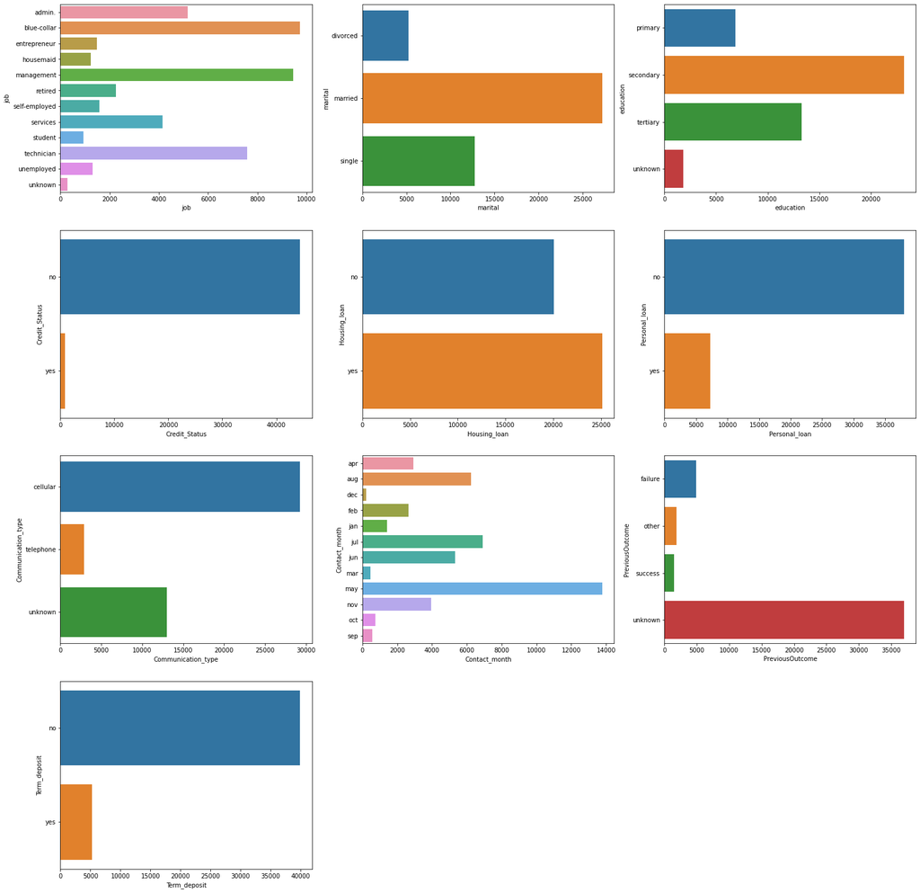

```python
# To plot all categorical features in a single plot

plt.figure(figsize=(25,80), facecolor='white')
plt.title("Countplot for Categorical data")
plotnumber=1
for categorical_feature in categorical_features:
  ax= plt.subplot(12,3,plotnumber)
  sns.countplot(y=categorical_feature,data=bm)
  plt.xlabel(categorical_feature)
  # plt.title(categorical_feature)
  plotnumber+=1
plt.show()
```

**Explanation:**

*Key Observations from Univariate Analysis From Categorical Columns*

We can identify Client who are **married** are contacted more by the bank and divorced Client have been contacted least followed by single category.

In **Job** Factor, we can observe that Client with blue-collar,management and technician jobs have been contacted more by the bank which are more than 6k

If we observe the plot, **secondary education** category is contacted most.

**Housing loan** category clients are more in number which may help in finding relationships with target variable

**personal loan** category shows nearly 7K customers are contacted.

The **Clients who are last contacted** are majorly in the month of may followed by july and august. Bank has least contacted the clients in the december followed by march,september and october.

The Plot on **contact communication type** explains bank has contacted clients mostly through cellular communication and least contacted through telephone communication. Also, there are nearly 14k clients where bank is unable to reach customers.

->>>The Plot on **outcome of the previous marketing campaign** contains 37K unknown values which is more imbalanced.

So removing columns from the dataset includes-> Credit Status, Outcome of previous marketing compaign which introude bias in analysis.

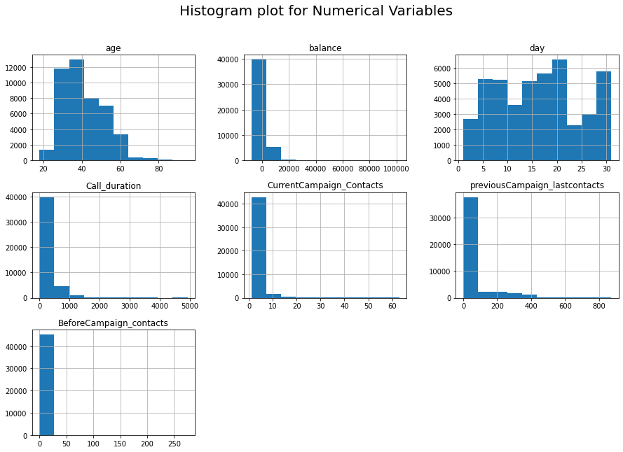

```python
bm.hist(figsize = (15,10)) # Histogram plot for Numerical Columns
plt.suptitle("Histogram plot for Numerical Variables",fontsize=20) # title of the Histogram plot
```

**Explanation:**

**By looking at the histogram subplots we can find analysis as below:**

**Age**- Moderately skewed towards right

**balance** - Positively Skewed or right skewed

**day**: Symmetrical

**duration** - Positively Skewed or right skewed

**CurrentCampaign Contacts** - Positively Skewed or right skewed

**PreviousCampaign lastcontact** - Positively Skewed or right skewed

**BeforeCampaign_contact** - Positively Skewed or right skewed

```python
bm.skew() # to find skewness value of all columns in dataset
```

```
age                               0.684818
balance                           8.360308
day                               0.093079
Call_duration                     3.144318
CurrentCampaign_Contacts          4.898650
previousCampaign_lastcontacts     2.615715
BeforeCampaign_contacts          41.846454
dtype: float64
```

# Skewness

- If skewness is between -0.5 and 0.5, the distribution is approximately symmetric.
- If skewness is between -1 and -0.5 or between 0.5 and 1, the distribution is moderately skewed.
- If skewness is less than -1 or greater than 1, the distribution is highly skewed.
- Now we can clearly check that balance, Call_duration, campaign, pdays and previous columns are highly skewed.
- Only Age variable is moderately skewed.
- day last contacted to the client is symmetrical

```python
bm.kurt() # Kurtosis of the variable
```

```
age                                 0.319570
balance                           140.751547
day                                -1.059897
Call_duration                      18.153915
CurrentCampaign_Contacts           39.249651
previousCampaign_lastcontacts       6.935195
BeforeCampaign_contacts          4506.860660
dtype: float64
```

**Kurtosis**

Lets walk you through what it this exactly and how it is going to effect for analysis and introduce problems

**Kurtosis** relates to the degree of presence of outliers in the distribution.

In finance, kurtosis is used as a measure of financial risk. A large kurtosis indicates high level of risk for an investment because it indicates that there are high probabilities of extremely large and extremely small returns. Also, a small kurtosis signals a moderate level of risk because the chances of extreme returns are relatively low.

From skewness and Kurtosis we got to understand that balance, duration, campaign, pdays, previous columns are highyly skewed and they introduce bias to the model.

```python
bm.columns
```

```
Index(['age', 'job', 'marital', 'education', 'Credit_Status', 'balance',
       'Housing_loan', 'Personal_loan', 'Communication_type', 'day',
       'Contact_month', 'Call_duration', 'CurrentCampaign_Contacts',
       'previousCampaign_lastcontacts', 'BeforeCampaign_contacts',
       'PreviousOutcome', 'Term_deposit'],
      dtype='object')
```

**Finding Relations between Independent and Dependant Variables and its effect on target column.**

**Independent Variables**

Age\ job\ marital\ education\ Balance\ Communication_type\ Contact_month\ Call_duration\ day of Contact\ PresentCampaign_contacts_made\ previousCampaign_lastcontacted\ BeforeCampaign_contact

**Dependent Variables**

Term_deposit\ Credit_Status\ Housing_Loan\ Personal_Loan\ PreviousOutcome

**Transforming - Encoding:**

*Encoding categorical features:* encodes categorical variables into 1s and 0s (yes and no become 1 and 0).

To find correlation for Credit_Status, Housing_loan, Personal_loan against Term_deposit how they effecting.

```python
# a. Encoding categorical features.
# bm1['Credit_Status'] = bm1['Credit_Status'].map({'yes': 1, 'no': 0})
# bm1['Housing_loan'] = bm1['Housing_loan'].map({'yes': 1, 'no': 0})
# bm1['Personal_loan'] = bm1['Personal_loan'].map({'yes': 1, 'no': 0})
# bm1
```

[output not shown]

```python
# bm1=bm.copy()
# bm1['Term_deposit'].replace(['no', 'yes'],
#                         [0, 1], inplace=True)
# bm1.value_counts('Term_deposit')
```

[output not shown]

```python
# col = ['Credit_Status', 'Housing_loan', 'Personal_loan'] # columns for conversion which are showing as object dataypes
# bm1[col]=bm1[col].astype('int')
# bm1.dtypes
```

[output not shown]

# Approach Taken-1

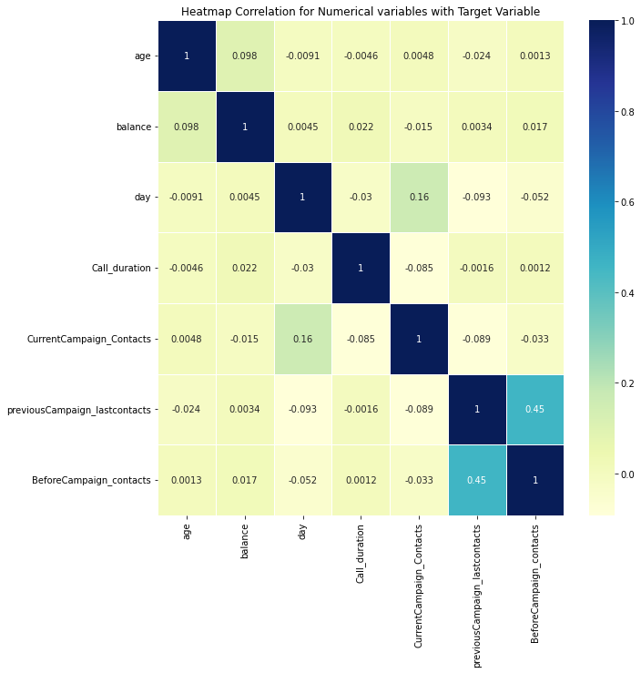

```python
fig, ax = plt.subplots(figsize=(10, 10))
sns.heatmap(bm.corr(),annot=True,ax=ax, linewidth=0.5,cmap="YlGnBu")
plt.title("Heatmap Correlation for Numerical variables with Target Variable")
plt.show()
```